# Developing Data Products Week 4 Assignment: Predicting Geyser Eruptions

José Manuel Mirás-Avalos

June 18, 2020

# Reproducible Pitch Presentation

As a part of the Week 4 assignment of the **Developing Data Products** course, this presentation is intended to describe the *Shiny App* that I created.

# Overview

The *Shiny App* employs the *faithful* data, which consists of the Waiting time between eruptions and the duration of the eruption for the Old Faithful geyser in Yellowstone National Park, Wyoming, USA.

The *Shiny App* plots the waiting time between eruptions as a function of their duration and fits a linear model.

- The user can select a value of eruption time from the slider to get the corresponding estimated waiting time for the next eruption
- The submit button must be clicked to get a response
- The fitted line can be displayed or not by clicking on the checkbox

# The Old Faithful dataset

```r
head(faithful)
```

```
##   eruptions waiting
## 1     3.600      79
## 2     1.800      54
## 3     3.333      74
## 4     2.283      62
## 5     4.533      85
## 6     2.883      55
```

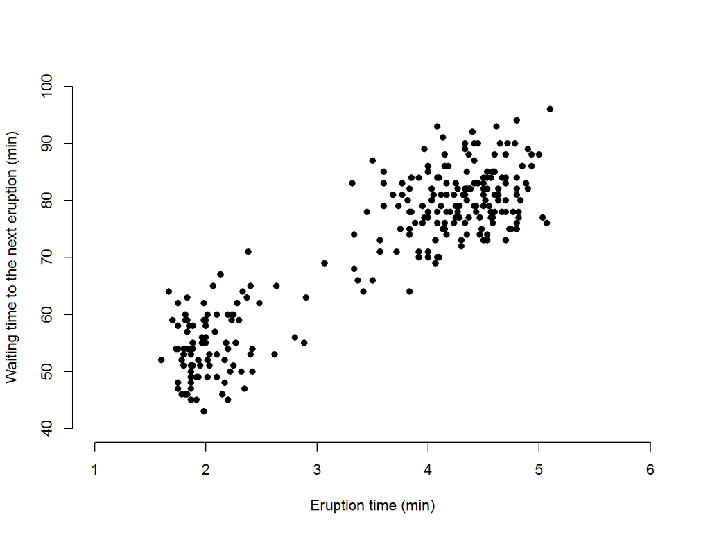

```r
 plot(faithful$eruptions, faithful$waiting, xlim = c(1,6), ylim = c(40,100), xlab= "Eruption time (min)", ylab = "Waiting time to the next eruption (min)", bty = "n", pch = 16)
```

# The Server.R code

```r
library(shiny)

# Define server logic required to draw a scatter plot
shinyServer(function(input, output) {
    model1 <- lm(waiting ~ eruptions, data = faithful)

    model1pred <- reactive({
        eruptionInput <- input$sliderEruption
        predict(model1, newdata = data.frame(eruptions = eruptionInput))
    })

    output$plot1 <- renderPlot({
    eruptionInput <- input$sliderEruption

    plot(faithful$eruptions, faithful$waiting, xlim = c(1,6), ylim = c(40,100), xlab= "Eruption time (min)", ylab = "Waiting time to the next eruption (min)", bty = "n", pch = 16)
    if(input$showModel1){
            abline(model1, col = "red", lwd = 2)
        }

        legend(1, 90,"Linear Model Prediction", col = "red", lwd = 2, bty = "n", cex = 1.1)
        points(eruptionInput, model1pred(), col = "red", pch = 16, cex = 1.6)
    })

        output$pred1 <- renderText({
            round(model1pred(),2)
        })

})
```